# Mini-Retiro Espiritual Online

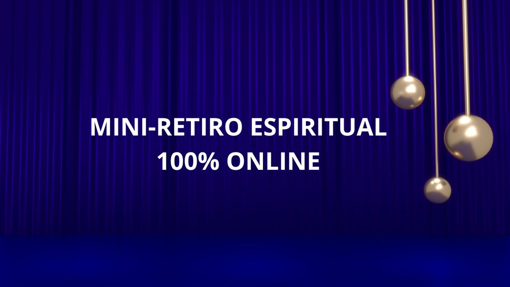

## Bem-vindo ao nosso Mini-Retiro Espiritual Online

Junte-se a nós nesta jornada transformadora de renovação espiritual e autoconhecimento.

Este Retiro tem por objetivo ajudar você a se preparar para o Final do Ano de 2024, fazendo uma Limpeza orgânica através da prática do Semi-Jejum, deixando você mais leve e com uma sensação maior de bem-estar físico; uma Limpeza Energética e Espiritual, através da Yoga Rúnica direcionada para a saúde e o bem-estar; das Orações, Decretos, Afirmações e Ativações para trazer equilíbrio e harmonia, proteção espiritual; das Meditações Guiadas para direcionar as energias positivas e elevadas para a Realização, Materialização, Concretização aqui no Plano Físico de seus sonhos, planos, projetos, metas e objetivos para 2025; e ainda, através das Leituras diárias - de mensagens, textos de Auto-Ajuda e outros, ampliando assim a sua consciência e o seu entendimento para aproveitar ainda mais esta oportunidade de crescimento e desenvolvimento pessoal, profissional e espiritual para 2025.

Este retiro foi cuidadosamente planejado para proporcionar uma experiência profunda de conexão interior, tudo isso no conforto do seu lar.

**O que você encontrará nesta jornada:** - Meditações guiadas por instrutor experiente - Prática de Yoga Rúnica - visando o bem-estar físico e energético - Momentos especiais de Leituras - expansão da consciência e Auto-Ajuda - Acompanhamento em Grupo e Individual - consoante as necessidades - Momentos de Sintonização com Orações, Decretos, Afirmações e Ativações

## Programação do Retiro

### Dia 14 de Dezembro de 2024 - Sábado

- 08h - Oração de Preparação das Energias para o dia;
- 08h:30min. - Pequeno-Almoço (Café da manhã);
- 10h - Yoga Rúnica - atividade Online em direto (participação do Grupo);
- 10h:30min. - Lanche;
- 12h/12h:30min. - Almoço;
- 14h - Leitura - mensagem, auto-ajuda, expansão de consciência (participação do Grupo);
- 16h - Lanche;
- 18h - Orações, Decretos, Afirmações e Ativações;
- 18h:30min. - Meditação Guiada - atividade Online em direto (participação do Grupo);
- 19:30 - Jantar;
- 21h:30min./22h - Ceia

### Dia 15 de Dezembro de 2024 - Domingo

- 08h - Oração de Preparação das Energias para o dia;
- 08h:30min. - Pequeno-Almoço (Café da manhã);
- 10h - Yoga Rúnica - atividade Online em direto (participação do Grupo);
- 10h:30min. - Lanche;
- 12h/12h:30min. - Almoço;
- 14h - Leitura - mensagem, auto-ajuda, expansão de consciência (participação do Grupo);
- 16h - Lanche;
- 18h - Orações, Decretos, Afirmações e Ativações;
- 18h:30min. - Meditação Guiada - atividade Online em direto (participação do Grupo);
- 19:30 - Jantar;
- 21h:30min./22h - Ceia

### Dia 16 de Dezembro de 2024 - Segunda

- 08h - Oração de Preparação das Energias para o dia;
- 08h:30min. - Pequeno-Almoço (Café da manhã);
- 10h - Yoga Rúnica - atividade Online em direto (participação do Grupo);
- 10h:30min. - Lanche;
- 12h/12h:30min. - Almoço;
- 14h - Leitura - mensagem, auto-ajuda, expansão de consciência (participação do Grupo);
- 16h - Lanche;
- 18h - Orações, Decretos, Afirmações e Ativações;
- 20h - Meditação Guiada - atividade Online em direto (participação do Grupo);
- 20h:30min./21h - Jantar

*Encerramento do Mini-Retiro Espiritual*

**ATENÇÃO:** - Todas as Atividades com participação do Grupo em direto (ao vivo) serão gravadas - A Yoga Rúnica, as Meditações Guiadas e as Leituras, para que os participantes possam acompanhar posteriormente em outros dias e horários disponíveis.

## Inicie Sua Jornada Interior

Vagas limitadas para garantir uma experiência mais profunda e personalizada.

PRÉ-INSCRIÇÃO (e Pagamento): Aproveite o VALOR PROMOCIONAL de Pré-Inscrição até o dia 04/12. Clique no link abaixo:

[📝 Inscreva-se aqui](https://forms.gle/VVSCpyzgAvuZhqv97) [📱 Fale Conosco](https://wa.me/969133326)